# Iteratif

maka perhitungan faktorial suatu bilangan dapat dilakukan dengan cara iterasi, yaitu mengmenghitung operasi perkalian mulai dari bilangan tersebut sampai dengan satu.

# Code

```python
def factorialIteratif(bilangan):

    if bilangan <= 1:
        return 1
    else:
        temp = bilangan
        hasil = 1

        while temp > 1:
            hasil = hasil * temp
            temp = temp - 1

        return hasil
print(factorialIteratif(4))
```

```
24
```

Suatu permasalahan akan lebih mudah dipecahkan jika permasalahan tersebut berukuran kecil. Misalkan pengurutan data akan lebih mudah dilakukan jika data yang diurutkan hanya terdiri dari dua buah data saja, sehingga pengurutan dapat dilakukan dengan membandingkan dua data tersebut saja. Rekursif merupakan suatu teknik pemrograman yang memecah permasalahan menjadi permasalahan dengan ukuran yang lebih kecil dan lebih kecil lagi, sehingga permasalahan dengan ukuran kecil tersebut dapat dengan mudah dipecahkan. Teknik ini dapat dilakukan dengan cara memanggil fungsi itu sendiri. Jika pada contoh sebelumnya, untuk menghitung suatu bilangan dapat dilakukan dengan menggunakan cara iterasi, maka berikut ini adalah penyelesaian perhitungan faktorial dengan cara rekursif. Misalkan hitung 5!, maka dapat dihitung dengan cara sebagai berikut,

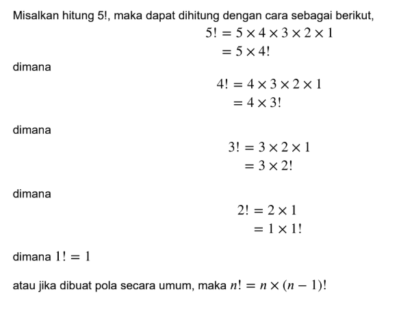

Berikut adalah code untuk perhitungan faktorial dengan cara rekursif

```python
def factorialRekursif(bilangan):

    if bilangan <= 1:
        return 1
    else:
        return bilangan * factorialRekursif(bilangan - 1)

data = factorialRekursif(4)
print(data)
```

```
24
```

Dari fungsi tersebut dapat dilihat bahwa teknik pemrograman rekursif ini melibatkan pemanggilan fungsinya itu sendiri dengan argument atau parameter yang berukuran lebih kecil. Berikut beberapa aturan dalam teknik pemrograman rekursif:

1. Fungsi rekursif harus memiliki base case, base case inilah yang berfungsi untuk menghentikan pemanggilan terus menerus fungsi rekursif
2. fungsi rekursif harus memiliki sintaks yang dapat merubah state dari permasalahan, sehingga semakin lama solusi permasalahan menuju base case yang sudah dibuat
3. Fungsi rekursif harus memanggil dirinya sendiri

# Implementasi Rekursif

Banyak permasalahan yang dapat diselesaikan dengan teknik pemrograman rekursif ini. Berikut contoh-contoh implementasi rekursif.

# Triangular Numbers

Terdapat deret bilangan berikut : 1, 3, 6, 10, 15, 21, 28, 36, ... Bagaimanakah pola bilangan tersebut ? Deret bilangan tersebut dikenal dengan nama Triangular Numbers, yang dapat diilustrasikan seperti Gambar 1 berikut.

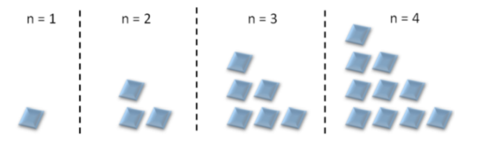

Bagaimana menentukan bilangan ke- dari deret tersebut ? Ilustrasi perhitungan deret keempat dari triangular numbers dapat dilihat pada Gambar 2 berikut:

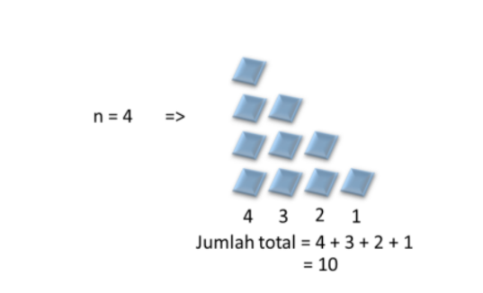

Gambar 2. Perhitungan Triangular Numbers

Dapat dilihat pada Gambar tersebut bahwa kolom pertama memiliki 4 kotak, kolom kedua memiliki 3 kotak, kolom ketiga memiliki 2 kotak, dan kolom terakhir memiliki 1 kotak, jumlah kotak total adalah 10, oleh karena itu deret ke-empat dari triangular numbers adalah 10. Berikut fungsi iteratif untuk mencari deret ke-n dari triangular numbers

Berikut adalah code untuk menghitung triangular numbers melalui teknik iteratif

```python
def triangularNumbers1(n):

    total = 0
    temp = n

    while temp >= 1:
        total += temp
        temp -= 1

    return total
print(triangularNumbers1(2))
```

```
3
```

Untuk mencari deret ke- dari triangular numbers, dapat juga digunakan fungsi rekursif seperti permasalahan perhitungan faktorial sebelumnya. Base case dari triangular numbers ini adalah ketika deret ke-1 yang bernilai 1. Berikut fungsi rekursif dari triangular numbers.

```python
def triangularNumbers2(n):

    if n == 1:
        return 1
    else:
        return n + triangularNumbers2(n - 1)
print(triangularNumbers1(8))
```

```
36
```

# Konversi Bilangan

Bilangan integer dikenal juga sebagai bilangan dengan base 10 (desimal), sehingga memiliki kemungkinan character angka dari 0 s.d 9. Sedangkan base 2 atau yang dikenal nama bilangan biner, hanya memiliki kemungkinan character angka 0 dan 1 saja. Base 8 atau octal, hanya memiliki character 0 s.d 7, sedangkan base 16 atau hexa, memiliki character angka mulai dari 0 s.d 9 dan 'A','B','C','D','E', dan 'F'. Masing-masing bilangan ini dapat dikonversikan menjadi bilangan base lain, akan tetapi yang sering digunakan adalah konversi bilangan desimal ke bilangan base yang lain, atau dari base 2, 8, 16 ke bilangan desimal. Berikut contoh konversi bilangan desimal ke bilangan base 2, 8, atau 16. Bilangan desimal 8 menjadi bilangan biner '1000'. Untuk merubah bilangan desimal 8 menjadi biner, diperlukan operasi pembagian dan modulo dari bilangan desimal tersebut.

Berikut fungsi rekursif untuk konversi bilangan desimal menjadi bilangan base yang lain.

```python
def konversiDesimal(bilangan, base):

    charBilangan = '0123456789ABCDEF'

    if bilangan < base:
        return charBilangan[bilangan]
    else:
        temp = bilangan // base
        ind = bilangan % base

        print(type(temp), temp, type(ind), ind)

        return konversiDesimal(temp, base) + charBilangan[ind]
konversiDesimal(5,2)
```

```
<class 'int'> 2 <class 'int'> 1
<class 'int'> 1 <class 'int'> 0
```

```
'101'
```

# Towers of Hanoi

Towers of Hanoi ini diinspirasi oleh cerita mitos dari sebuah kuil di India. Pada saat itu, pendeta memerintahkan para pekerjanya atau pendeta muda untuk memindahkan 64 piringan emas dengan ukuran yang berbeda-beda dari satu tiang ke tiang lainnya. Syarat memindahkan piringan emas ini adalah :

1. piringan emas harus dipindahkan satu persatu
2. piringan emas berukuran kecil harus berada diatas piringan emas berukuran besar. Piringan emas dan tiang, dapat diilustrasikan pada Gambar 3 berikut :

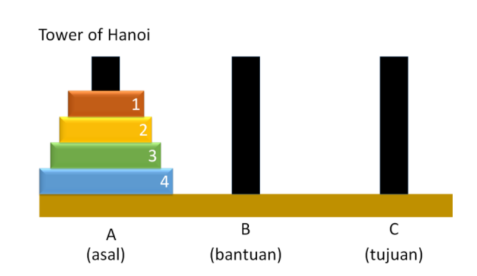

   Mitos mengatakan bahwa, ketika tugas ini selesai, maka kuil akan lenyap dan dunia akan hilang. Tetapi ini hanya mitos saja, dan untuk memindahkan piringan emas satu persatu itu membutuhkan waktu milyaran tahun. Pemindahan piringan emas tersebut akan mudah, jika hanya 1 buah piringan saja yang akan dipindahkan. Misalkan, terdapat 4 buah piringan terdapat di tiang 'A' dan akan dipindahkan ke tiang 'C', dan ada tiang 'B' sebagai bantuan. Untuk memindahkan 4 piringan tersebut dari tiang A ke tiang C, bukanlah hal yang mudah. Akan tetapi jika diasumsikan, bahwa 3 buah piringan teratas dapat dipindahkan secara langsung dari tiang A ke tiang B, maka piringan ke-4 dapat dengan mudah dipindahkan dari tiang A ke tiang C. Permasalahan berikutnya muncul adalah, bagaimana memindahkan 3 buah piringan dari tiang A ke tiang B. Hal ini dapat dengan mudah dilakukan jika dua buah piringan dapat dipindahkan dari tiang A ke tiang C, sehingga piringan ketiga dapat dipindahkan dari tiang A ke tiang B. Proses ini dapat dilakukan secara terus menerus hingga, hanya terdapat sebuah piringan saja yang akan dipindahkan dari satu tiang ke tiang lainnya (seperti halnya proses rekursif),

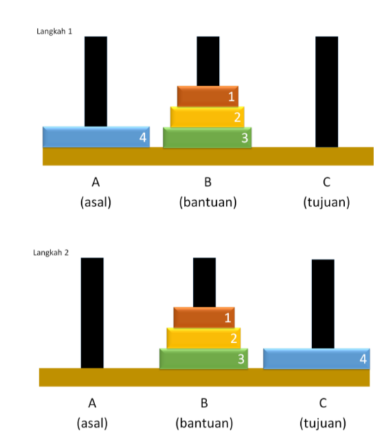

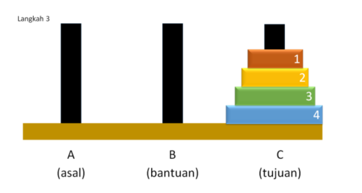

Berikut code untuk penyelesaian permasalahan towers of hanoi dengan menggunakan teknik rekursif

```python
def towers(n, awal, bantuan, tujuan):

    if n == 1:
        print("Piringan - 1 dari-", awal, "ke-", tujuan)
    else:
        towers(n - 1, awal, tujuan, bantuan)

        print("Piringan -", n, "dari-", awal, "ke-", tujuan)

        towers(n - 1, bantuan, awal, tujuan)

towers(4,'A','B','C')
```

```
Piringan - 1 dari- A ke- B
Piringan - 2 dari- A ke- C
Piringan - 1 dari- B ke- C
Piringan - 3 dari- A ke- B
Piringan - 1 dari- C ke- A
Piringan - 2 dari- C ke- B
Piringan - 1 dari- A ke- B
Piringan - 4 dari- A ke- C
Piringan - 1 dari- B ke- C
Piringan - 2 dari- B ke- A
Piringan - 1 dari- C ke- A
Piringan - 3 dari- B ke- C
Piringan - 1 dari- A ke- B
Piringan - 2 dari- A ke- C
Piringan - 1 dari- B ke- C
```

# Visualisasi Teknik Pemrograman Rekursif

Rekursif juga dapat digunakan untuk kepentingan visualisasi. Banyak gambar yang dapat dihasilkan dengan cara rekursif ini. Gambar dari pemrograman rekursif dapat dilakukan dengan bantuan modul Turtle. Turtle merupakan module yang dapat digunakan oleh bahasa pemrograman Python versi apapun. Module ini dapat diumpamakan seperti seekor turtle, yang dapat bergerak maju, mundur, ke kanan, ke kiri, dan sebagainya. Turtle dapat mengambar jika ekornya down, sehingga ekor ini akan meninggalkan jejak (gambar) ketika turtle bergerak. Turtle tidak dapat menggambar jika ekornya up. Ekor ini dapat diumpamakan sebagai sebuah pena, yang dapat juga diatur warna maupun ukurannya. Untuk menggunakan module turtle ini, maka harus import turtle terlebih dahulu, seperti contoh-contoh berikut.

Code Berikut adalah pembuatan bentuk spiral secara rekursif dengan menggunakan modul Turtle

```python
import turtle

my_turtle = turtle.Turtle()
my_win = turtle.Screen()

def draw_spiral(my_turtle, line_len):

    if line_len > 0:
        my_turtle.forward(line_len)
        my_turtle.right(90)

        draw_spiral(my_turtle, line_len - 5)

draw_spiral(my_turtle, 90)

my_win.exitonclick()
```

# Segitiga Sierpinski

Segitia Sierpinski ini juga merupakan bentuk fraktal. Segitiga ini memiliki bentuk dasar (yaitu, suatu segitiga dan didalamnya terdapat empat buat segitiga dengan ukuran yang sama), dan bentuk dasar ini terus menerus dibangkitkan sampai derajat tertentu.

Code Berikut contoh code untuk pembuatan Segitiga Sierpinski

```python
import turtle

def draw_triangle(points, color, my_turtle):

    my_turtle.speed('slowest')
    my_turtle.fillcolor(color)

    my_turtle.up()
    my_turtle.goto(points[0][0], points[0][1])
    my_turtle.down()

    my_turtle.begin_fill()

    my_turtle.goto(points[1][0], points[1][1])
    my_turtle.goto(points[2][0], points[2][1])
    my_turtle.goto(points[0][0], points[0][1])

    my_turtle.end_fill()

def get_mid(p1, p2):

    return ((p1[0] + p2[0]) / 2,
            (p1[1] + p2[1]) / 2)

def sierpinski(points, degree, my_turtle):

    color_map = [
        "blue", "red", "green",
        "white", "yellow", "violet", "orange"
    ]

    draw_triangle(points, color_map[degree], my_turtle)

    if degree > 0:

        sierpinski(
            [points[0],
             get_mid(points[0], points[1]),
             get_mid(points[0], points[2])],
            degree - 1,
            my_turtle
        )

        sierpinski(
            [points[1],
             get_mid(points[0], points[1]),
             get_mid(points[1], points[2])],
            degree - 1,
            my_turtle
        )

        sierpinski(
            [points[2],
             get_mid(points[2], points[1]),
             get_mid(points[0], points[2])],
            degree - 1,
            my_turtle
        )

def main():

    my_turtle = turtle.Turtle()
    my_win = turtle.Screen()

    my_points = [[-100, -50], [0, 100], [100, -50]]

    sierpinski(my_points, 2, my_turtle)

    my_win.exitonclick()

main()
```